# Проверка базы данных бентосных проб в Финском заливе

В. М. Хайтов

2023-02-12

## Таблица данных по обилию видов

В таблице данных обнаружены следующие проблемы, которые требуют согласования.

1. Следует ли свести в одну группу свести *Macoma balthica* и *Macoma balthica* juv.? В таблице исходных данных они значатся как *Lemicola balthica*, что уже пересмотрено (WoRMS).
2. Следует ли свести в одну группу *Gammarus* sp. juv. *Gammarus* sp.?
3. *Urospora norvegica* такого вида нет в базах данных (WORMS, GBIF). Предлагается использовать название *Urospora* sp.
4. *Jaera* sp. *Jaera albifrons* Почти наверняка неверное определение *Jaera albifrons*, в этом регионе, скорее надо ожидать *J.ischiosetosa*. Может лучше свести все к *Jaera* sp.
5. “Oligochaeta кокон” предлагаю удалить из анализа.
6. *Gammarus salinus*, *Mya arenaria*, Mysidacea, *Neomysis awatschensis*, Odonata, отсутствует биомасса и численность. Предлагаю удалить их из анализа.
7. На станциях SN6, SN7, 19-GFKop-8 суммарная численность равна нулю, а суммарная биомасса не равна нулю.
8. На станции IA25 у *Monoporeia* есть биомасса но нет численности. Это только один из примеров, на которой я наткнулся так как с этой станцией были и другие проблемы и я ее просмотрел более внимательно. Вероятно таких случаев, когда есть биомасса но нет численности, довольно много. В связи предлагаю в качестве основного показателя обилия использовать биомассу.
9. На станции 19-GFKop-9 суммарная численность не равна нулю, а суммарная биомасса ноль.
10. На большом количестве станций суммарная численность и суммарная биомасса равны нулю. Это безжизненные пробы или что-то другое?

## Карта и координаты станций

**Важно!** В исходной базе данных перепутаны широта и долгота. Я это исправил, но надо смотреть не проникли ли ошибки и в другие базы.

После нанесения точек сбора на карту стало видно, что материал очень гетерогенен. Подавляющее большинство станций находится в вершине Финского залива. Лишь немногие располагаются в его открытой части. Я предлагаю разделить всю совокупность станций на две части: явно морская часть (несколько станций в центральной части залива) и все остальное. В дальнейшем анализе сосредоточится на второй части проб. Соответственно, карта будет отражать меньший участок, будет более детальной.

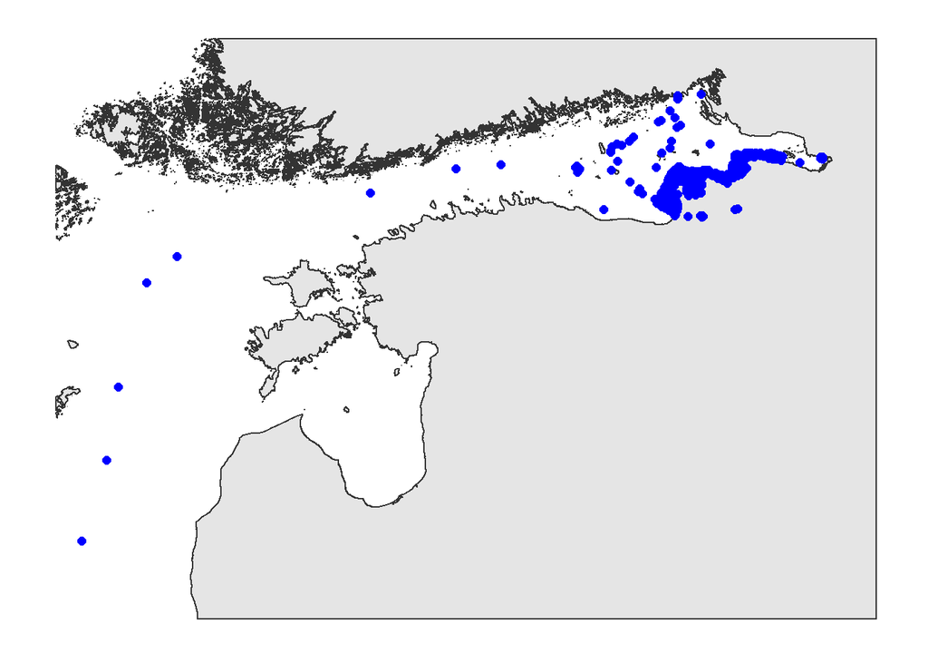

## Проблемы с координатами станций

Видно, что целый ряд станций попал на сушу. Такое бывает при использовании карманных GPS-навигаторов. Ну и плюс ошибки в записи. Необходимо скорректировать координаты следующих станций.

Станции, у которых надо проверить координаты

| sampling_station_name | sampling_date | lat | long |
| --- | --- | --- | --- |
| 19-GFLuVy-1 | 2019-08-20 | 59.67956 | 28.23965 |
| 19-GFLuVy-2 | 2019-08-20 | 59.68016 | 28.24000 |
| 19-GFLuDu-5a | 2019-08-20 | 59.73740 | 28.44235 |
| 19-GFNbGa-1 | 2019-08-20 | 59.65570 | 28.02475 |
| 19-GFKopBe-1 | 2019-08-20 | 59.82328 | 28.60259 |
| 19-GFKopSP-1 | 2019-08-20 | 59.80628 | 28.90870 |
| 19-GFGrBay-1 | 2019-08-20 | 59.98141 | 29.20626 |
| 19-GFNS2Nb-1 | 2019-09-01 | 59.65998 | 28.08723 |
| 19-GFKop-19 | 2019-09-30 | 59.83392 | 29.01367 |
| 19-GFKop-19A | 2019-09-30 | 59.83392 | 29.01367 |
| 19-GFKop-20 | 2019-09-30 | 59.83223 | 29.01088 |
| 19-GFKop-21 | 2019-09-30 | 59.83938 | 29.02332 |
| 19-GFKop-24 | 2019-09-30 | 59.85913 | 29.04958 |
| 19-GFKop-28 | 2019-09-30 | 59.85235 | 29.04042 |
| 20-GFLuNa-1 | 2020-06-09 | 59.77436 | 28.13077 |
| 20-GFVybRi-1 | 2020-07-22 | 59.67602 | 28.22037 |
| 20-GFVybRi-2 | 2020-07-22 | 59.67577 | 28.22109 |
| 20-GFLuRi-1 | 2020-07-22 | 59.65351 | 28.25721 |
| 20-GFLuRi-2 | 2020-07-22 | 59.65366 | 28.25682 |
| 20-GFKovRi-1 | 2020-07-24 | 59.88489 | 29.09329 |
| 20-GFSisRi-1 | 2020-07-24 | 59.75446 | 28.81624 |
| B46A | 2020-08-26 | 59.47815 | 28.45470 |
| 20-GFLuRi-3 | 2020-08-28 | 59.65160 | 28.25627 |
| A1 | 2020-09-23 | 59.52874 | 28.07737 |
| 21-GFLuNa-2 | 2021-06-28 | 59.77612 | 28.12952 |
| 21-GFLuRi-5 | 2021-06-28 | 59.65148 | 28.25428 |
| 21-GFLuzRi-2 | 2021-06-28 | 59.65590 | 28.35172 |
| 21-GFKhaRi-1 | 2021-06-29 | 59.67605 | 28.43335 |
| 21-GFKhaRi-2 | 2021-06-29 | 59.67488 | 28.43413 |
| 21-GFKhaRi-2 | 2021-06-29 | 59.67488 | 28.43413 |
| 21-GFVybRi-3 | 2021-06-29 | 59.67618 | 28.24992 |
| 21-GFVybRi43 | 2021-06-29 | 59.67712 | 28.22437 |
| 21-ПМ-15 | 2021-07-27 | 59.97812 | 30.20265 |
| 150 | 2021-08-15 | 59.81770 | 28.64242 |
| 152 | 2021-08-15 | 59.80933 | 28.66257 |
| 156 | 2021-08-15 | 59.47401 | 28.42310 |
| 147 | 2021-08-15 | 59.82688 | 28.58327 |
| 154 | 2021-08-15 | 59.79827 | 28.67460 |
| 155 | 2021-08-15 | 59.47450 | 28.41737 |
| 158 | 2021-08-15 | 59.46502 | 28.43899 |
| 159 | 2021-08-15 | 59.46831 | 28.46306 |
| 183 | 2021-08-16 | 59.79198 | 28.13000 |
| 21-GFLiLi-1 | 2021-08-16 | 59.78585 | 28.16807 |
| 21-GFVybRi-7 | 2021-08-16 | 59.67988 | 28.23987 |
| 193 | 2021-08-17 | 59.74777 | 28.02558 |
| 300 | 2021-08-17 | 59.47795 | 28.04418 |
| 301 | 2021-08-17 | 59.49048 | 28.05412 |
| 303 | 2021-08-17 | 59.54198 | 28.08690 |
| 304 | 2021-08-17 | 59.52043 | 28.07603 |
| 305 | 2021-08-17 | 59.53142 | 28.08140 |
| 194 | 2021-08-17 | 59.73103 | 28.03747 |
| 306 | 2021-08-17 | 59.55547 | 28.08950 |
| Kol-1 | 2021-08-18 | 59.84828 | 28.54263 |
| Kol-2 | 2021-08-18 | 59.84040 | 28.51958 |
| Kol-3 | 2021-08-18 | 59.83057 | 28.49643 |
| Kol-4 | 2021-08-18 | 59.82817 | 28.47713 |
| 18 | 2021-08-26 | 59.52720 | 28.92863 |
| 28 | 2021-08-26 | 59.53718 | 28.96708 |
| 77 | 2021-08-31 | 59.47078 | 28.24235 |

## Точки, попадающие в пределы сухопутных полигонов карты

Некоторые из точек легли на кромку берега, но лучше и этого избегать.

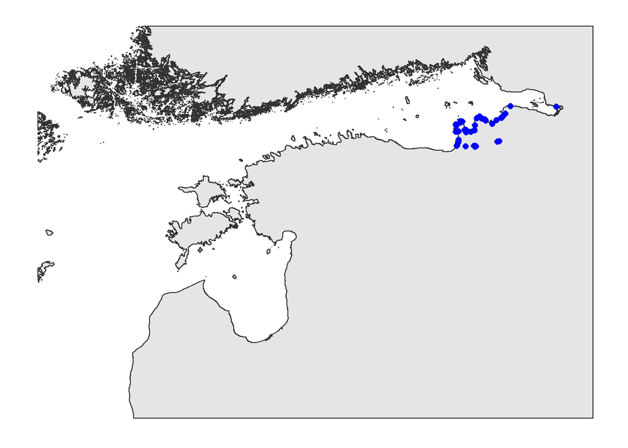